# feather river redd data exploration

2024-08-27

Goal of this document is to review the Feather River redd data and understand the following:

- what data are collected?
- what is the quality of the data?
- what are the data limitations?
- how are these data useful to Science Plan hypotheses?

## Relevant Science Plan hypotheses

1. Spawning habitat acreage
- **From Science Plan:** “The metric for this hypothesis will be the acreage of spawning habitat with suitable water depths and velocities, and sizes of spawning gravel. Spawning habitat criteria, including depth, velocity, and target spawning substrate size will be defined in the specific VA action science and monitoring plan and associated design documents. The suitable gravel size for spawning habitat will be a range and distribution of spawning substrate sizes specific to the spawning population and hydrogeomorphic conditions in each tributary.”
- **Ideas:** This hypothesis was set up to use depth and velocity criteria to map spawning habitat acreage and compare to existing habitat. We could map spawning habitat based on redd locations over time. We would need latitude and longitude of all redds observed.
2. Salmon redd density (this is the most relevant hypothesis)
- **From Science Plan:** “The metric for this hypothesis will be the number of Chinook salmon redds per unit area in habitat enhancement project areas, while also accounting for the potential for redd superimposition. The baseline for this hypothesis will be the redd density and superimposition rate at habitat enhancement locations compared to adjacent areas within the same reach, measured concurrently along with water quality criteria. In systems where redd mapping has been conducted consistently at both project locations and adjacent, non-enhanced locations, historical data can also be leveraged to examine trends and changes in redd density after the enhancement action.”
- **Ideas:** This is the number of redds per unit area. We would need a count of redds and some sort of delineation of the area where redds are occurring (this could be latitude/longitude of redd or river mile/reach surveyed, assuming whole area is surveyed)
3. Natural origin adult Chinook salmon population estimates by tributary, and trend in abundance (harvest plus escapement)
- **From Science Plan:** “The metric for this hypothesis will be annual natural-origin adult Chinook salmon cohort replacement rates and trends over multiple years (e.g., > 3 years) over the period of VA implementation. The baseline for this hypothesis will be the annual natural-origin adult Chinook salmon cohort replacement rate trends during the period associated with the Anadromous Fish Restoration Program Doubling Goal (years 1967-1991). A secondary baseline, to reflect recent conditions and population numbers, will be annual adult Chinook salmon cohort replacement rates and trends for natural-origin fall run Chinook salmon since 2010.”
- **Ideas:** We would need high quality redd data in order to estimate adult population

*Contact*

These data were originally acquired from Chris Cook

*Timeframe*

### Data quality

```
## Rows: 7,323
## Columns: 19
## $ date            <dttm> 2023-09-26 10:07:00, 2023-09-18 10:20:00, 2023-09-18 …
## $ survey_wk       <chr> "1-1", "1-1", "1-1", "1-1", "1-1", "1-1", "1-1", "2-2"…
## $ location        <chr> "Moe's Side Channel", "Moe's Side Channel", "Moe's Sid…
## $ file_number     <lgl> NA, NA, NA, NA, NA, NA, NA, NA, NA, NA, NA, NA, NA, NA…
## $ type            <chr> NA, NA, NA, NA, NA, NA, NA, NA, NA, NA, NA, NA, NA, NA…
## $ number_redds    <dbl> 1, 2, 1, NA, 0, 0, NA, 0, 2, 0, 1, 2, 0, NA, NA, 1, 0,…
## $ number_salmon   <lgl> NA, NA, NA, NA, NA, NA, NA, NA, NA, NA, NA, NA, NA, NA…
## $ latitude_m_n    <dbl> 39.51610, 39.51598, 39.51602, 39.51694, 39.51779, 39.5…
## $ longitude_m_e   <dbl> -121.5581, -121.5592, -121.5592, -121.5539, -121.5517,…
## $ depth_m         <dbl> 0.25, 0.46, 0.47, 0.40, NA, NA, NA, 0.46, 0.60, 0.40, …
## $ pot_depth_m     <lgl> NA, NA, NA, NA, NA, NA, NA, NA, NA, NA, NA, NA, NA, NA…
## $ velocity_m_s    <dbl> 0.680, 0.650, 0.348, 0.728, NA, NA, NA, 0.643, 0.185, …
## $ percent_fines   <dbl> 5, 5, 0, 20, NA, NA, NA, 0, 0, 0, 0, NA, NA, NA, NA, 0…
## $ percent_small   <dbl> 30, 55, 40, 20, NA, NA, NA, 45, 35, 35, 55, 65, NA, NA…
## $ percent_med     <dbl> 50, 20, 45, 20, NA, NA, NA, 45, 65, 60, 35, 35, NA, NA…
## $ percent_large   <dbl> 15, 20, 15, 20, NA, NA, NA, 5, 0, 5, 0, 0, NA, NA, NA,…
## $ percent_boulder <dbl> 0, 0, 0, 20, NA, NA, NA, 5, 0, 0, 0, 0, NA, NA, NA, 0,…
## $ redd_width_m    <dbl> 1.0, 1.0, 1.2, 0.7, NA, NA, NA, 0.9, 1.7, 1.9, 1.4, 1.…
## $ redd_length_m   <dbl> 1.5, 1.0, 1.5, 1.2, NA, NA, NA, 2.4, 2.8, 2.8, 3.0, 2.…
```

### Data questions

All coordinates, except 2023, are on mn me format, transforming to UTM here #TODO continue to look into the lat/long that did not tranform

```
## Rows: 29,553
## Columns: 19
## $ date            <dttm> 2014-09-09, 2014-09-09, 2014-09-15, 2014-09-15, 2014-…
## $ survey_wk       <chr> "1-1", "1-1", "2-1", "2-1", "2-1", "2-1", "2-1", "2-1"…
## $ location        <chr> "Moe's Side Channel", "Upper Cottonwood", "Cottonwood"…
## $ file_number     <dbl> 1, 2, 1, 2, 3, 4, 5, 6, 7, 8, 9, 10, 11, 12, 13, 14, 1…
## $ type            <chr> "p", "p", "p", "p", "p", "p", "p", "p", "p", "p", "p",…
## $ number_redds    <dbl> 0, 1, 1, 1, 1, 1, 1, 1, 1, 1, 1, 1, 1, 1, 1, 1, 1, 1, …
## $ number_salmon   <dbl> 1, 1, 1, 0, 3, 0, 0, 0, 0, 0, 0, 1, 0, 0, 0, 0, 0, 1, …
## $ latitude_m_n    <dbl> 4375043, 4375121, 4375108, 4375106, 4375110, 4375113, …
## $ longitude_m_e   <dbl> 6239424.4, 624284.0, 624147.7, 624150.0, 624158.1, 624…
## $ depth_m         <dbl> 0.30, 0.62, NA, NA, NA, NA, NA, NA, NA, NA, NA, 0.72, …
## $ pot_depth_m     <dbl> 0.50, 0.70, NA, NA, NA, NA, NA, NA, NA, NA, NA, 0.76, …
## $ velocity_m_s    <dbl> 0.61, 0.89, NA, NA, NA, NA, NA, NA, NA, NA, NA, 0.55, …
## $ percent_fines   <dbl> 40, 0, NA, NA, NA, NA, NA, NA, NA, NA, NA, 0, 0, 0, 0,…
## $ percent_small   <dbl> 20, 65, NA, NA, NA, NA, NA, NA, NA, NA, NA, 40, 40, 60…
## $ percent_med     <dbl> 35, 30, NA, NA, NA, NA, NA, NA, NA, NA, NA, 50, 60, 20…
## $ percent_large   <dbl> 5, 5, NA, NA, NA, NA, NA, NA, NA, NA, NA, 10, 0, 10, 0…
## $ percent_boulder <dbl> 0, 0, NA, NA, NA, NA, NA, NA, NA, NA, NA, 0, 0, 10, 0,…
## $ redd_width_m    <dbl> 1.1, 2.5, NA, NA, NA, NA, NA, NA, NA, NA, NA, 1.5, 2.0…
## $ redd_length_m   <dbl> 2.0, 3.5, NA, NA, NA, NA, NA, NA, NA, NA, NA, 2.0, 2.5…
```

```
## Simple feature collection with 29553 features and 17 fields
## Geometry type: POINT
## Dimension:     XY
## Bounding box:  xmin: -127.4887 ymin: 0 xmax: -69.95373 ymax: 39.69579
## Geodetic CRS:  WGS 84
## # A tibble: 29,553 × 18
##    date                survey_wk location         file_number type  number_redds
##  * <dttm>              <chr>     <chr>                  <dbl> <chr>        <dbl>
##  1 2014-09-09 00:00:00 1-1       Moe's Side Chan…           1 p                0
##  2 2014-09-09 00:00:00 1-1       Upper Cottonwood           2 p                1
##  3 2014-09-15 00:00:00 2-1       Cottonwood                 1 p                1
##  4 2014-09-15 00:00:00 2-1       Cottonwood                 2 p                1
##  5 2014-09-15 00:00:00 2-1       Cottonwood                 3 p                1
##  6 2014-09-15 00:00:00 2-1       Cottonwood                 4 p                1
##  7 2014-09-15 00:00:00 2-1       Cottonwood                 5 p                1
##  8 2014-09-15 00:00:00 2-1       Cottonwood                 6 p                1
##  9 2014-09-15 00:00:00 2-1       Cottonwood                 7 p                1
## 10 2014-09-15 00:00:00 2-1       Cottonwood                 8 p                1
## # ℹ 29,543 more rows
## # ℹ 12 more variables: number_salmon <dbl>, depth_m <dbl>, pot_depth_m <dbl>,
## #   velocity_m_s <dbl>, percent_fines <dbl>, percent_small <dbl>,
## #   percent_med <dbl>, percent_large <dbl>, percent_boulder <dbl>,
## #   redd_width_m <dbl>, redd_length_m <dbl>, geometry <POINT [°]>
```

```
## # A tibble: 6 × 21
##   date                survey_wk location          file_number type  number_redds
##   <dttm>              <chr>     <chr>                   <dbl> <chr>        <dbl>
## 1 2014-09-09 00:00:00 1-1       Moe's Side Chann…           1 p                0
## 2 2014-09-09 00:00:00 1-1       Upper Cottonwood            2 p                1
## 3 2014-09-15 00:00:00 2-1       Cottonwood                  1 p                1
## 4 2014-09-15 00:00:00 2-1       Cottonwood                  2 p                1
## 5 2014-09-15 00:00:00 2-1       Cottonwood                  3 p                1
## 6 2014-09-15 00:00:00 2-1       Cottonwood                  4 p                1
## # ℹ 15 more variables: number_salmon <dbl>, latitude_m_n <dbl>,
## #   longitude_m_e <dbl>, depth_m <dbl>, pot_depth_m <dbl>, velocity_m_s <dbl>,
## #   percent_fines <dbl>, percent_small <dbl>, percent_med <dbl>,
## #   percent_large <dbl>, percent_boulder <dbl>, redd_width_m <dbl>,
## #   redd_length_m <dbl>, longitude <dbl>, latitude <dbl>
```

Combining all years into one object

```
## Rows: 36,876
## Columns: 19
## $ date            <dttm> 2014-09-09, 2014-09-09, 2014-09-15, 2014-09-15, 2014-…
## $ survey_wk       <chr> "1-1", "1-1", "2-1", "2-1", "2-1", "2-1", "2-1", "2-1"…
## $ location        <chr> "Moe's Side Channel", "Upper Cottonwood", "Cottonwood"…
## $ file_number     <dbl> 1, 2, 1, 2, 3, 4, 5, 6, 7, 8, 9, 10, 11, 12, 13, 14, 1…
## $ type            <chr> "p", "p", "p", "p", "p", "p", "p", "p", "p", "p", "p",…
## $ number_redds    <dbl> 0, 1, 1, 1, 1, 1, 1, 1, 1, 1, 1, 1, 1, 1, 1, 1, 1, 1, …
## $ number_salmon   <dbl> 1, 1, 1, 0, 3, 0, 0, 0, 0, 0, 0, 1, 0, 0, 0, 0, 0, 1, …
## $ latitude_m_n    <dbl> 4375043, 4375121, 4375108, 4375106, 4375110, 4375113, …
## $ longitude_m_e   <dbl> 6239424.4, 624284.0, 624147.7, 624150.0, 624158.1, 624…
## $ depth_m         <dbl> 0.30, 0.62, NA, NA, NA, NA, NA, NA, NA, NA, NA, 0.72, …
## $ pot_depth_m     <dbl> 0.50, 0.70, NA, NA, NA, NA, NA, NA, NA, NA, NA, 0.76, …
## $ velocity_m_s    <dbl> 0.61, 0.89, NA, NA, NA, NA, NA, NA, NA, NA, NA, 0.55, …
## $ percent_fines   <dbl> 40, 0, NA, NA, NA, NA, NA, NA, NA, NA, NA, 0, 0, 0, 0,…
## $ percent_small   <dbl> 20, 65, NA, NA, NA, NA, NA, NA, NA, NA, NA, 40, 40, 60…
## $ percent_med     <dbl> 35, 30, NA, NA, NA, NA, NA, NA, NA, NA, NA, 50, 60, 20…
## $ percent_large   <dbl> 5, 5, NA, NA, NA, NA, NA, NA, NA, NA, NA, 10, 0, 10, 0…
## $ percent_boulder <dbl> 0, 0, NA, NA, NA, NA, NA, NA, NA, NA, NA, 0, 0, 10, 0,…
## $ redd_width_m    <dbl> 1.1, 2.5, NA, NA, NA, NA, NA, NA, NA, NA, NA, 1.5, 2.0…
## $ redd_length_m   <dbl> 2.0, 3.5, NA, NA, NA, NA, NA, NA, NA, NA, NA, 2.0, 2.5…
```

```
## tibble [36,876 × 19] (S3: tbl_df/tbl/data.frame)
##  $ date           : POSIXct[1:36876], format: "2014-09-09" "2014-09-09" ...
##  $ survey_wk      : chr [1:36876] "1-1" "1-1" "2-1" "2-1" ...
##  $ location       : chr [1:36876] "Moe's Side Channel" "Upper Cottonwood" "Cottonwood" "Cottonwood" ...
##  $ file_number    : num [1:36876] 1 2 1 2 3 4 5 6 7 8 ...
##  $ type           : chr [1:36876] "p" "p" "p" "p" ...
##  $ number_redds   : num [1:36876] 0 1 1 1 1 1 1 1 1 1 ...
##  $ number_salmon  : num [1:36876] 1 1 1 0 3 0 0 0 0 0 ...
##  $ latitude_m_n   : num [1:36876] 4375043 4375121 4375108 4375106 4375110 ...
##  $ longitude_m_e  : num [1:36876] 6239424 624284 624148 624150 624158 ...
##  $ depth_m        : num [1:36876] 0.3 0.62 NA NA NA NA NA NA NA NA ...
##  $ pot_depth_m    : num [1:36876] 0.5 0.7 NA NA NA NA NA NA NA NA ...
##  $ velocity_m_s   : num [1:36876] 0.61 0.89 NA NA NA NA NA NA NA NA ...
##  $ percent_fines  : num [1:36876] 40 0 NA NA NA NA NA NA NA NA ...
##  $ percent_small  : num [1:36876] 20 65 NA NA NA NA NA NA NA NA ...
##  $ percent_med    : num [1:36876] 35 30 NA NA NA NA NA NA NA NA ...
##  $ percent_large  : num [1:36876] 5 5 NA NA NA NA NA NA NA NA ...
##  $ percent_boulder: num [1:36876] 0 0 NA NA NA NA NA NA NA NA ...
##  $ redd_width_m   : num [1:36876] 1.1 2.5 NA NA NA NA NA NA NA NA ...
##  $ redd_length_m  : num [1:36876] 2 3.5 NA NA NA NA NA NA NA NA ...
```

### Data exploration

Exploring fields that have data consistently

#### date

```
## [1] "2014-09-09 00:00:00 UTC" "2023-11-29 14:59:00 UTC"
```

#### location

- Location clean up is needed. There are some names that appear less than 5 times. We could check if they correspond to another location name, and it is spelled differently

```
##
##                         Aleck                  Aleck Riffle
##                            90                            32
##                       Bedrock                Bedrock Riffle
##                           898                          1982
##           Below Big hole East           Below Big Hole East
##                             1                            58
##        Below Lower Auditorium                       Big Bar
##                           481                            33
##                Big Bar Riffle                 Big Hole East
##                            24                           274
##                 Big Hole West                    Big Riffle
##                            47                           104
##                    Cottonwood                    Developing
##                          1214                             4
##             Developing Riffle                           Eye
##                             3                            42
##              Eye Side Channel G-95 East Side Channel Bottom
##                           107                             1
##                 G-95 East Top                     G-95 Main
##                             1                             1
## G-95 West Side Channel Bottom               G95 East Bottom
##                             1                           137
##  G95 East Side Channel Bottom     G95 East side Channel Top
##                            66                             4
##     G95 East Side Channel Top                  G95 East Top
##                            30                           103
##                      G95 Main                      G95 West
##                            67                            40
##               G95 West Bottom         G95 West Side Channel
##                             1                            23
##                       Gateway          Gateway Main Channel
##                            42                            15
##          Gateway Side Channel                         Goose
##                             8                            22
##                  Goose Riffle                 Great Western
##                             7                             7
##                      Hatchery                 Hatchery Pipe
##                          1594                           892
##               Hatchery Riffle         Hatchery Side Channel
```

[output cut: 34 more lines]

```
##                             2                           644
##                Upper Hatchery         Upper Hatchery Riffle
##                           696                           909
##                    Upper Hour               Upper Hour east
##                            99                             2
##                 Upper Mathews                Upper Matthews
##                           134                            33
##               Upper Mcfarland               Upper McFarland
##                             2                            36
##                Upper Robinson                    Vance East
##                           843                           169
##                    Vance West                          Weir
##                            50                           105
##                   Weir Riffle
##                           168
```

```
##  [1] "Moe's Side Channel"            "Upper Cottonwood"
##  [3] "Cottonwood"                    "Lower Auditorium"
##  [5] "Top of Auditorium"             "Upper Hatchery Riffle"
##  [7] "Upper Auditorium"              "Mid Auditorium"
##  [9] "Hatchery Riffle"               "Developing Riffle"
## [11] "Upper McFarland"               "Big Riffle"
## [13] "G95 East Bottom"               "G95 Main"
## [15] "Big Hole East"                 "Vance East"
## [17] "Below Big Hole East"           "Upper Hour east"
## [19] "Upper Hour"                    "Mid Hour"
## [21] "Keister"                       "Big Bar"
## [23] "Lower McFarland"               "Middle Auditorium"
## [25] "Upper Hatchery"                "Hatchery"
## [27] "Hatchery Side Channel"         "Table Mountain"
## [29] "Goose"                         "G95 West Side Channel"
```

[output cut: 29 more lines]

**Locations surveyed less than 5 times**

For locations that are being surveyed less than five times, we might want to verify if they belong to other location area names. Otherwise, these sites might not have enough data to reliably analyze over time.

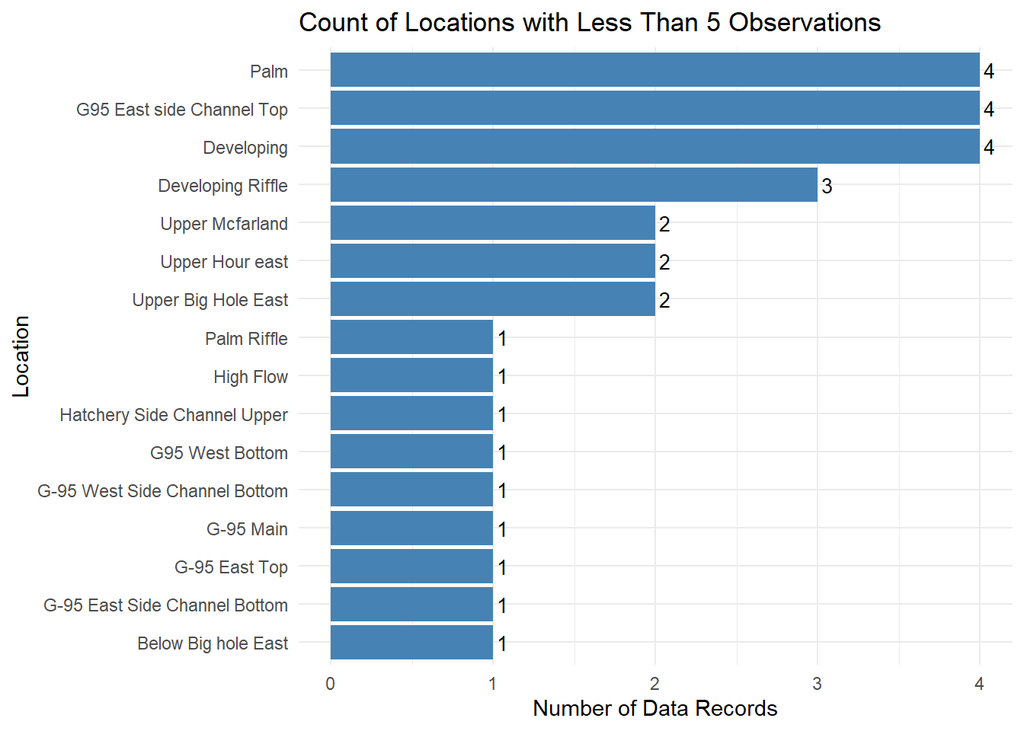

**Frequent locations and years surveyed**

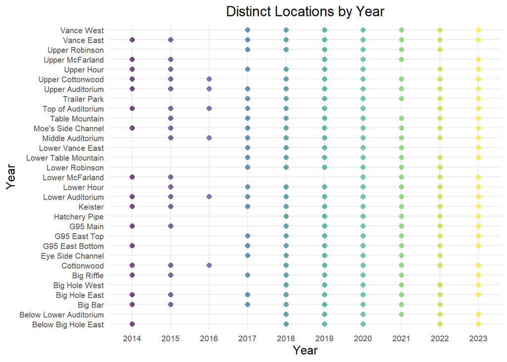

#### type

**Observations by type and date**

```
## [1] "p" "a" NA
```

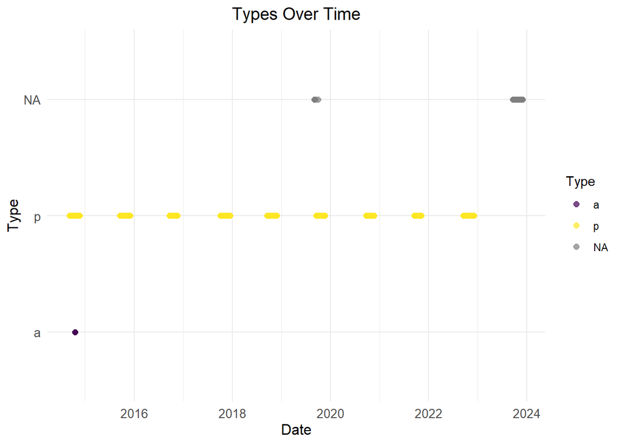

**Count of observations by type**

- note that all 2023 data does not have a `type` field

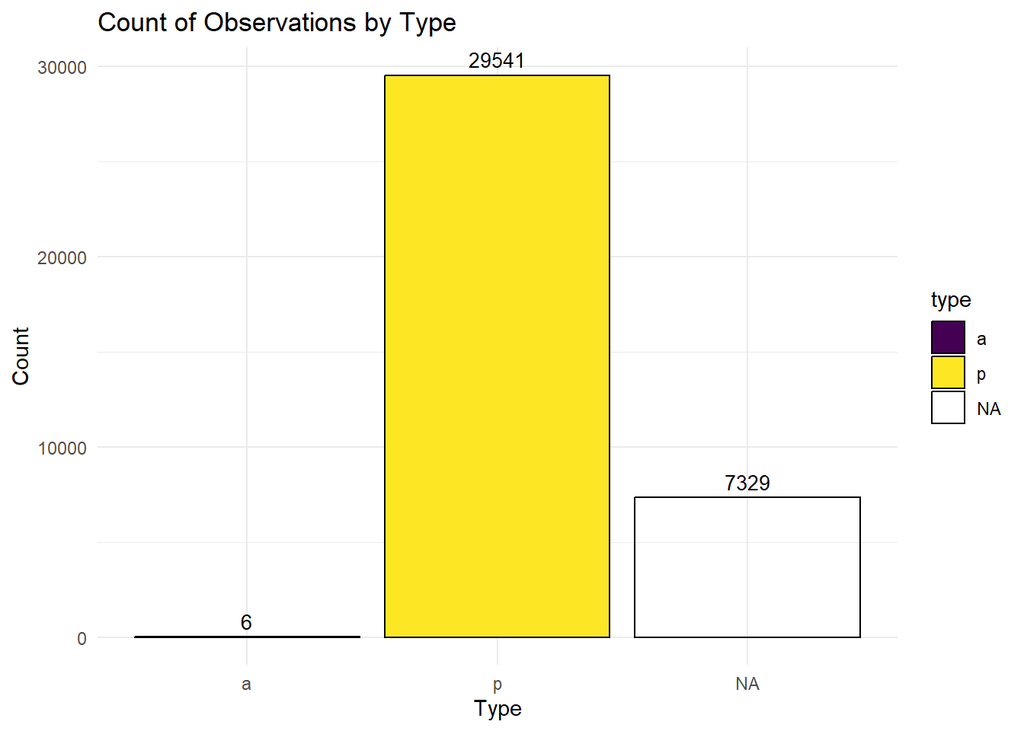

#### redd_count

**Redd counts by year**

```
## [1]  0 15
```

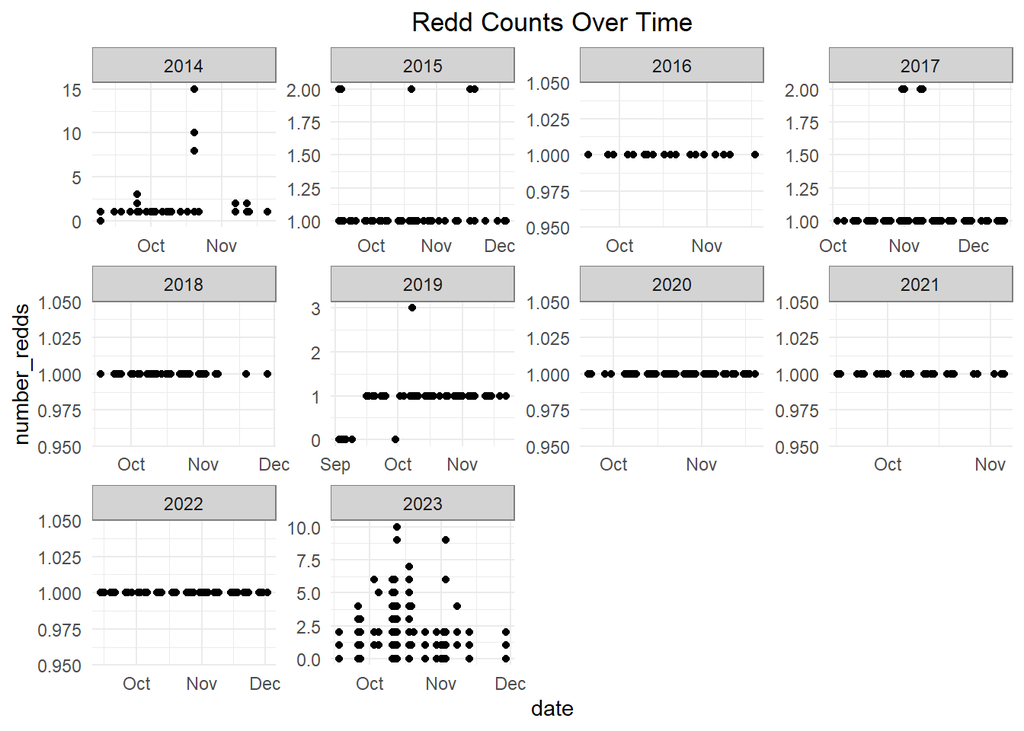

Same plot than above but with date values aggregated - using geom_col()

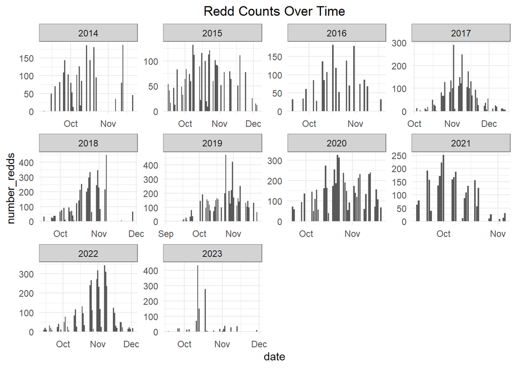

#### salmon_count

**Salmon counts by year**

```
## [1]  0 50
```

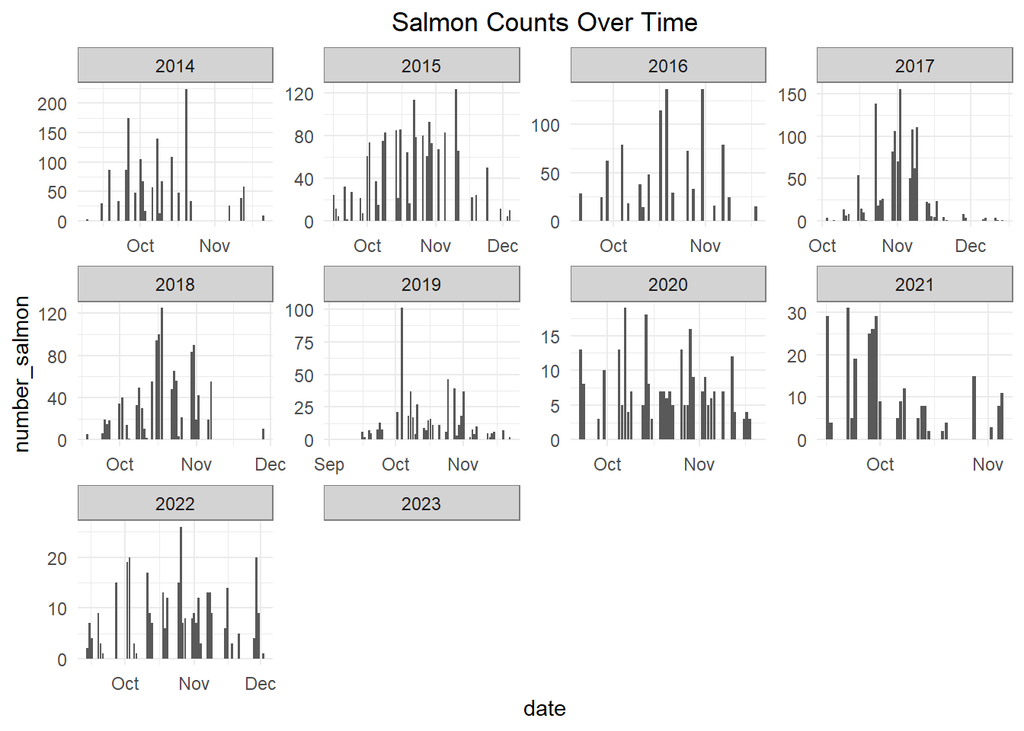

Latitude and longitude needs to be transformed to UTM #TODO